# Churn

Data_Training

9 de abril de 2019

```r
remove(list = ls())
```

# Cargar librerias necesarias

```r
if(!require(pacman)) install.packages("pacman")
```

```r
pacman::p_load("tidyverse",
               "MAS",
               "car",
               "e1071",
               "caret",
               "cowplot",
               "caTools",
               "pROC",
               "ggcorrplot",
               "dplyr",
               "tydyr",
               "string",
               "bitops",
               "haven",
               "rpart",
               "rpart.plot",
               "randomForest")
```

```
##
##  C:\Users\darocha\AppData\Local\Temp\RtmpuuOuNk\downloaded_packages
```

```
##
## tidyverse installed
```

### Inspección de la base de datos

Revisamos número de observaciones contenida en la base de datos, así como el tipo de objeto que es cada variable en R.

```r
glimpse(telco) # Tenemos 7043 observaciones con 21 variables.
```

```
## Observations: 7,043
## Variables: 21
## $ customerID       <fct> 7590-VHVEG, 5575-GNVDE, 3668-QPYBK, 7795-CFOC...
## $ gender           <fct> Female, Male, Male, Male, Female, Female, Mal...
## $ SeniorCitizen    <int> 0, 0, 0, 0, 0, 0, 0, 0, 0, 0, 0, 0, 0, 0, 0, ...
## $ Partner          <fct> Yes, No, No, No, No, No, No, No, Yes, No, Yes...
## $ Dependents       <fct> No, No, No, No, No, No, Yes, No, No, Yes, Yes...
## $ tenure           <int> 1, 34, 2, 45, 2, 8, 22, 10, 28, 62, 13, 16, 5...
## $ PhoneService     <fct> No, Yes, Yes, No, Yes, Yes, Yes, No, Yes, Yes...
## $ MultipleLines    <fct> No phone service, No, No, No phone service, N...
## $ InternetService  <fct> DSL, DSL, DSL, DSL, Fiber optic, Fiber optic,...
## $ OnlineSecurity   <fct> No, Yes, Yes, Yes, No, No, No, Yes, No, Yes, ...
## $ OnlineBackup     <fct> Yes, No, Yes, No, No, No, Yes, No, No, Yes, N...
## $ DeviceProtection <fct> No, Yes, No, Yes, No, Yes, No, No, Yes, No, N...
## $ TechSupport      <fct> No, No, No, Yes, No, No, No, No, Yes, No, No,...
## $ StreamingTV      <fct> No, No, No, No, No, Yes, Yes, No, Yes, No, No...
## $ StreamingMovies  <fct> No, No, No, No, No, Yes, No, No, Yes, No, No,...
## $ Contract         <fct> Month-to-month, One year, Month-to-month, One...
## $ PaperlessBilling <fct> Yes, No, Yes, No, Yes, Yes, Yes, No, Yes, No,...
## $ PaymentMethod    <fct> Electronic check, Mailed check, Mailed check,...
## $ MonthlyCharges   <dbl> 29.85, 56.95, 53.85, 42.30, 70.70, 99.65, 89....
## $ TotalCharges     <dbl> 29.85, 1889.50, 108.15, 1840.75, 151.65, 820....
## $ Churn            <fct> No, No, Yes, No, Yes, Yes, No, No, Yes, No, N...
```

### Ahora inspeccionamos cuáles variables tienen N/A’s

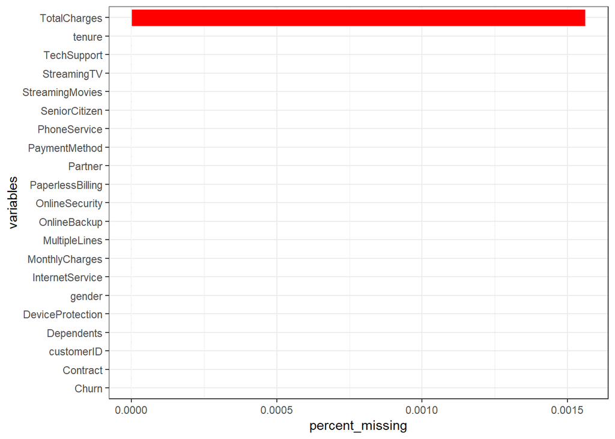

```r
# options(repr.plot.width = 6, repr.plot.height = 4)
missing_data <- telco %>% summarise_all(funs(sum(is.na(.))/n()))
missing_data <- tidyr::gather(missing_data, key = "variables", value = "percent_missing")
p <- ggplot(missing_data, aes(x = reorder(variables, percent_missing), y = percent_missing)) +
  geom_bar(stat = "identity", fill = "red", aes(color = I('white')), size = 0.3)+
  xlab('variables')+
  coord_flip()+
  theme_bw()
print(p)
```

Solo hay 11 datos faltantes en el campo TotalCharges, Las filas asociadas a estos datos ser?n eliminados.

```r
telco <- telco[complete.cases(telco),]
```

La base tiene 3 variables continuas: Tenencia, Cargos mensuales y Cargos totales. Mientras que SeniorCitizen est? en la forma ‘int’, la cu?l podemos volver cat?gorica.

```r
telco$SeniorCitizen <- as.factor(ifelse(telco$SeniorCitizen==1, 'YES', 'NO'))
```

# EXPLORATORY DATA ANALYSIS:

```r
theme1 <- theme_bw()+
  theme(axis.text.x = element_text(angle = 0, hjust = 1, vjust = 0.5),legend.position="none")
theme2 <- theme_bw()+
  theme(axis.text.x = element_text(angle = 90, hjust = 1, vjust = 0.5),legend.position="none")

glimpse(telco)
```

```
## Observations: 7,032
## Variables: 21
## $ customerID       <fct> 7590-VHVEG, 5575-GNVDE, 3668-QPYBK, 7795-CFOC...
## $ gender           <fct> Female, Male, Male, Male, Female, Female, Mal...
## $ SeniorCitizen    <fct> NO, NO, NO, NO, NO, NO, NO, NO, NO, NO, NO, N...
## $ Partner          <fct> Yes, No, No, No, No, No, No, No, Yes, No, Yes...
## $ Dependents       <fct> No, No, No, No, No, No, Yes, No, No, Yes, Yes...
## $ tenure           <int> 1, 34, 2, 45, 2, 8, 22, 10, 28, 62, 13, 16, 5...
## $ PhoneService     <fct> No, Yes, Yes, No, Yes, Yes, Yes, No, Yes, Yes...
## $ MultipleLines    <fct> No phone service, No, No, No phone service, N...
## $ InternetService  <fct> DSL, DSL, DSL, DSL, Fiber optic, Fiber optic,...
## $ OnlineSecurity   <fct> No, Yes, Yes, Yes, No, No, No, Yes, No, Yes, ...
## $ OnlineBackup     <fct> Yes, No, Yes, No, No, No, Yes, No, No, Yes, N...
## $ DeviceProtection <fct> No, Yes, No, Yes, No, Yes, No, No, Yes, No, N...
## $ TechSupport      <fct> No, No, No, Yes, No, No, No, No, Yes, No, No,...
## $ StreamingTV      <fct> No, No, No, No, No, Yes, Yes, No, Yes, No, No...
## $ StreamingMovies  <fct> No, No, No, No, No, Yes, No, No, Yes, No, No,...
## $ Contract         <fct> Month-to-month, One year, Month-to-month, One...
## $ PaperlessBilling <fct> Yes, No, Yes, No, Yes, Yes, Yes, No, Yes, No,...
## $ PaymentMethod    <fct> Electronic check, Mailed check, Mailed check,...
## $ MonthlyCharges   <dbl> 29.85, 56.95, 53.85, 42.30, 70.70, 99.65, 89....
## $ TotalCharges     <dbl> 29.85, 1889.50, 108.15, 1840.75, 151.65, 820....
## $ Churn            <fct> No, No, Yes, No, Yes, Yes, No, No, Yes, No, N...
```

# VISUALIZING THE CATEGORICAL DATA FIRST WITH RESPECT TO CHURN:

Las columnas de CHURN nos informan sobre la cantidad de clientes que se fueron en el ?ltimo mes. Alrededor del 26% de los clientes abandonaron la plataforma en el ?ltimo mes.

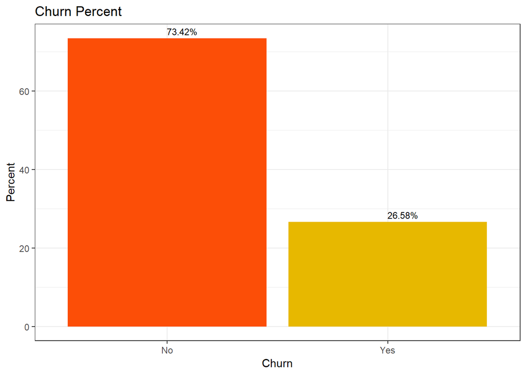

```r
options(repr.plot.width = 6, repr.plot.height = 4)
telco %>%
  group_by(Churn) %>%
  summarise(Count = n())%>%
  mutate(percent = prop.table(Count)*100)%>%
  ggplot(aes(reorder(Churn, -percent), percent), fill = Churn)+
  geom_col(fill = c("#FC4E07", "#E7B800"))+
  geom_text(aes(label = sprintf("%.2f%%", percent)), hjust = 0.01,vjust = -0.5, size =3)+
  theme_bw()+
  xlab("Churn") +
  ylab("Percent")+
  ggtitle("Churn Percent")
```

Género: el porcentaje de abandono es casi igual en el caso de hombres y mujeres El porcentaje de abandono es mayor en el caso de las personas mayores Los clientes con Socios y Dependientes tienen una tasa de abandono m?s baja en comparaci?n con los que no tienen socios y Dependientes.

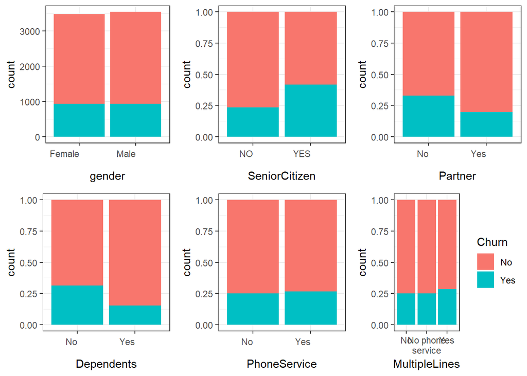

```r
# options(repr.plot.width = 12, repr.plot.height = 8)
plot_grid(ggplot(telco, aes(x=gender,fill=Churn))+ geom_bar()+ theme1,
          ggplot(telco, aes(x=SeniorCitizen,fill=Churn))+ geom_bar(position = 'fill')+theme1,
          ggplot(telco, aes(x=Partner,fill=Churn))+ geom_bar(position = 'fill')+theme1,
          ggplot(telco, aes(x=Dependents,fill=Churn))+ geom_bar(position = 'fill')+theme1,
          ggplot(telco, aes(x=PhoneService,fill=Churn))+ geom_bar(position = 'fill')+theme1,
          ggplot(telco, aes(x=MultipleLines,fill=Churn))+ geom_bar(position = 'fill')+theme_bw()+
            scale_x_discrete(labels = function(x){stringr::str_wrap(x, width = 10)}),
          align = "h")
```

La tasa de abandono es mucho mayor en el caso de los servicios de Internet de fibra óptica. Los clientes que no tienen servicios como: No OnlineSecurity, OnlineBackup y TechSupport han abandonado la plataforma en el último mes.

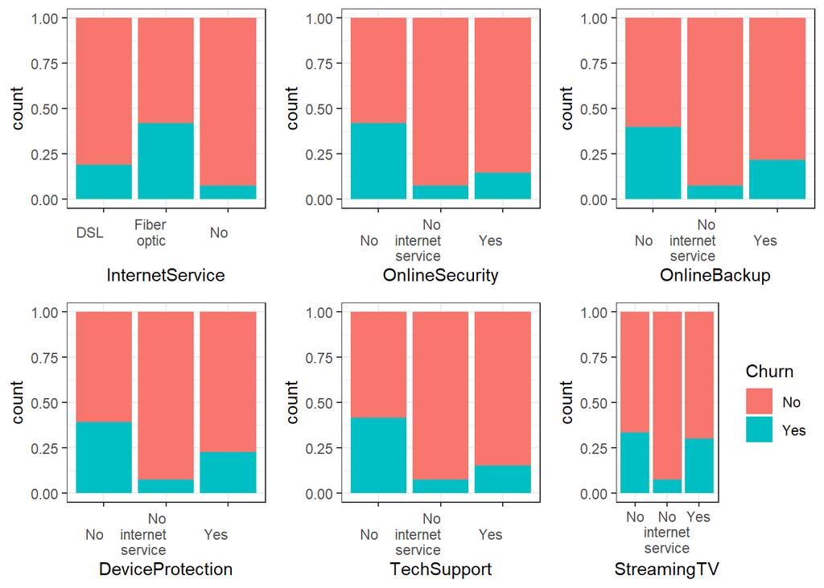

```r
# options(repr.plot.width = 12, repr.plot.height = 8)
plot_grid(ggplot(telco, aes(x=InternetService,fill=Churn))+ geom_bar(position = 'fill')+ theme1+
            scale_x_discrete(labels = function(x){stringr::str_wrap(x, width = 10)}),
          ggplot(telco, aes(x=OnlineSecurity,fill=Churn))+ geom_bar(position = 'fill')+theme1+
            scale_x_discrete(labels = function(x){stringr::str_wrap(x, width = 10)}),
          ggplot(telco, aes(x=OnlineBackup,fill=Churn))+ geom_bar(position = 'fill')+theme1+
            scale_x_discrete(labels = function(x){stringr::str_wrap(x, width = 10)}),
          ggplot(telco, aes(x=DeviceProtection,fill=Churn))+ geom_bar(position = 'fill')+theme1+
            scale_x_discrete(labels = function(x){stringr::str_wrap(x, width = 10)}),
          ggplot(telco, aes(x=TechSupport,fill=Churn))+ geom_bar(position = 'fill')+theme1+
            scale_x_discrete(labels = function(x){stringr::str_wrap(x, width = 10)}),
          ggplot(telco, aes(x=StreamingTV,fill=Churn))+ geom_bar(position = 'fill')+theme_bw()+
            scale_x_discrete(labels = function(x){stringr::str_wrap(x, width = 10)}),
          align = "h")
```

Un mayor porcentaje de clientes con suscripci?n mensual se han ido en comparaci?n con aquellos que tienen contrato de uno o dos a?os. El porcentaje de abandono es mayor en el caso de los clientes que tienen opciones de facturaci?n electr?nica. Los clientes que tienen el m?todo de pago ElectronicCheck tienden a abandonar la plataforma m?s en comparaci?n que con otras opciones.

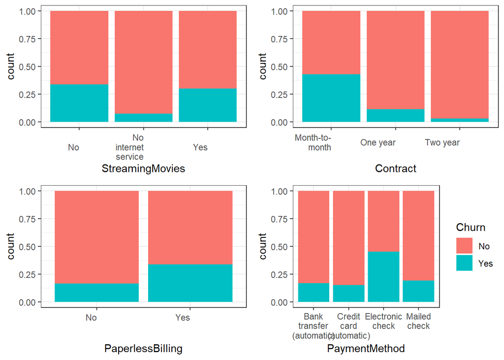

```r
plot_grid(ggplot(telco, aes(x=StreamingMovies,fill=Churn))+
            geom_bar(position = 'fill')+ theme1+
            scale_x_discrete(labels = function(x){stringr::str_wrap(x, width = 10)}),
          ggplot(telco, aes(x=Contract,fill=Churn))+
            geom_bar(position = 'fill')+theme1+
            scale_x_discrete(labels = function(x){stringr::str_wrap(x, width = 10)}),
          ggplot(telco, aes(x=PaperlessBilling,fill=Churn))+
            geom_bar(position = 'fill')+theme1+
            scale_x_discrete(labels = function(x){stringr::str_wrap(x, width = 10)}),
          ggplot(telco, aes(x=PaymentMethod,fill=Churn))+
            geom_bar(position = 'fill')+theme_bw()+
            scale_x_discrete(labels = function(x){stringr::str_wrap(x, width = 10)}),
          align = "h")
```

# ANÁLISIS DE LAS VARIABLES CONTINUAS

Tenure: La tenencia media para los clientes que han dejado es de alrededor de 10 meses.

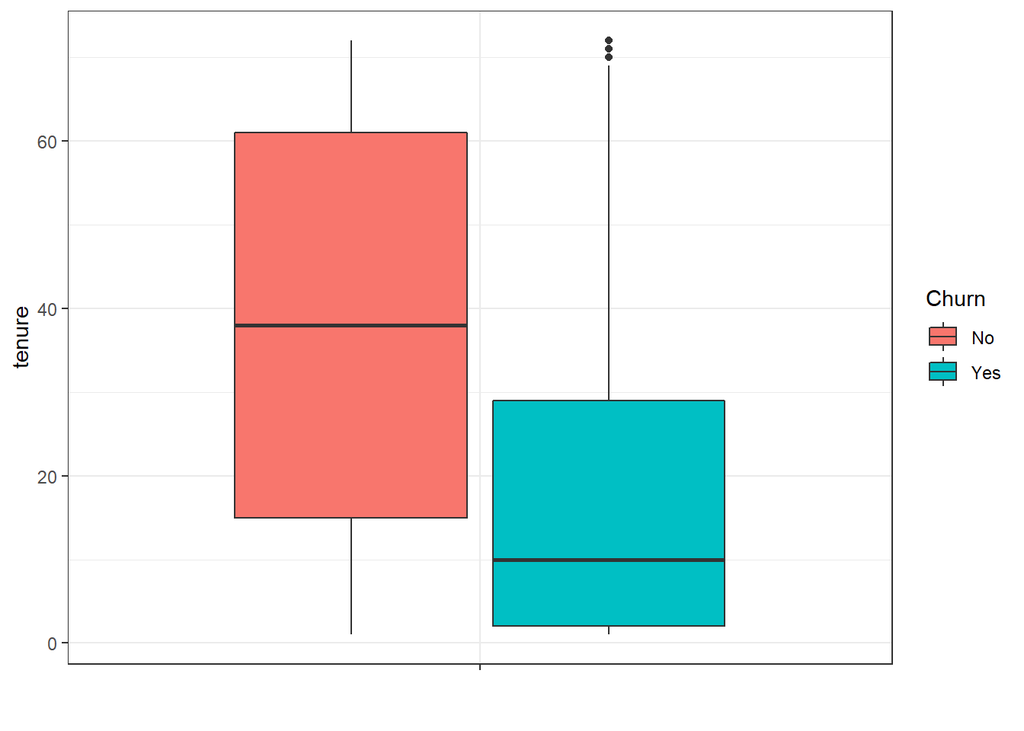

```r
# options(repr.plot.width =6, repr.plot.height = 2)
ggplot(telco, aes(y= tenure, x = "", fill = Churn)) +
  geom_boxplot()+
  theme_bw()+
  xlab(" ")
```

MonthlyCharges: Los clientes que se han ido son los que m?s cargos mensuales tienen. La mediana está por encima de 75.

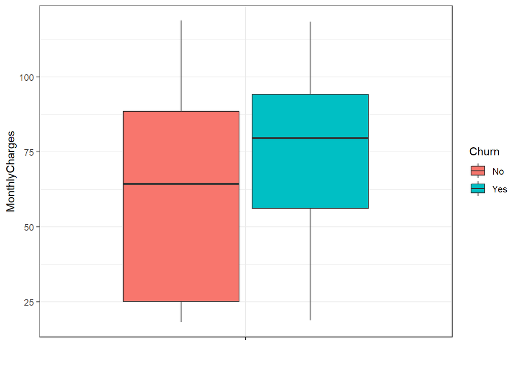

```r
ggplot(telco, aes(y= MonthlyCharges, x = "", fill = Churn)) +
  geom_boxplot()+
  theme_bw()+
  xlab(" ")
```

TotalCharges: La mediana de los cargos totales de los clientes que se han ido es bajo.

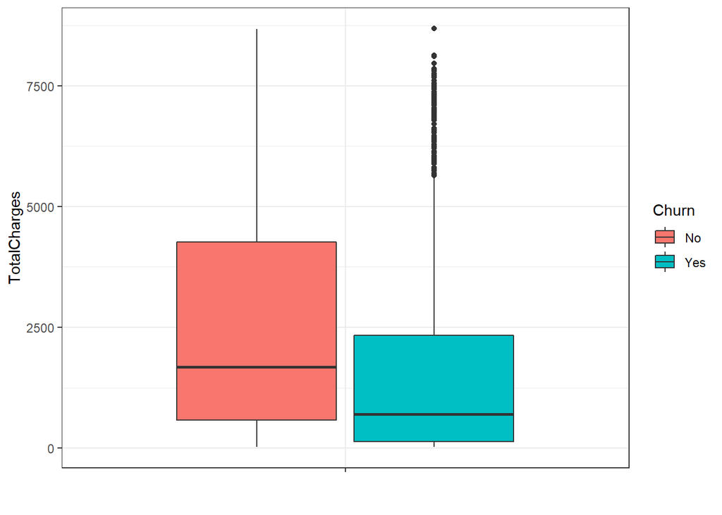

```r
ggplot(telco, aes(y= TotalCharges, x = "", fill = Churn)) +
  geom_boxplot()+
  theme_bw()+
  xlab(" ")
```

Revisando la correlación entre las variables continuas. Total Charges tienen una correlaci?n posiva con MonthlyCharges y Tenure.

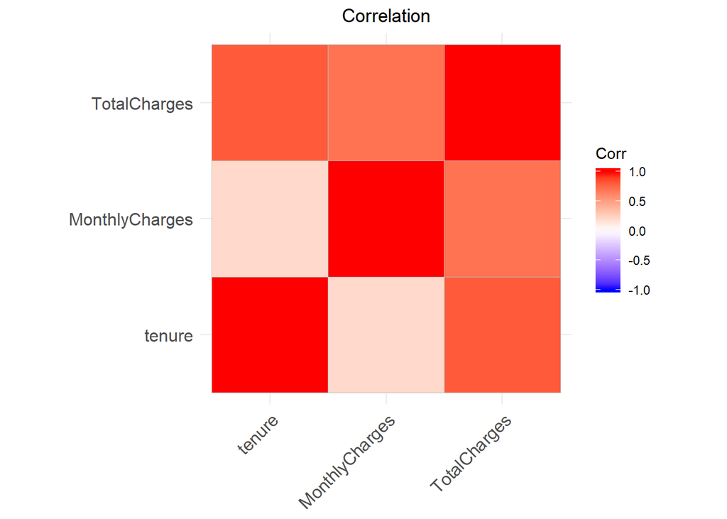

```r
# options(repr.plot.width =6, repr.plot.height = 4)
telco_cor <- round(cor(telco[,c("tenure", "MonthlyCharges", "TotalCharges")]), 1)
ggcorrplot(telco_cor,  title = "Correlation")+theme(plot.title = element_text(hjust = 0.5))
```

### Revisamos los outliers de las variables continuas:

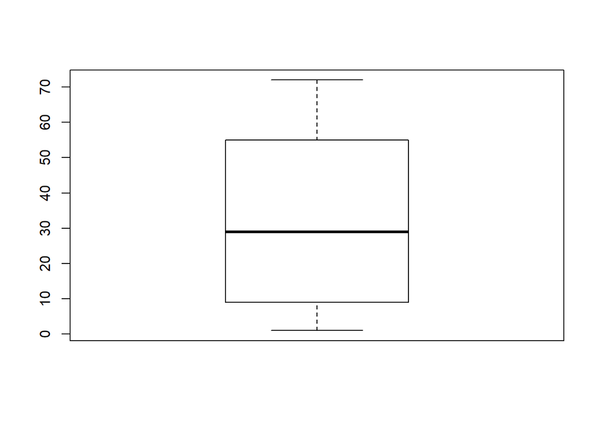

```
## numeric(0)
```

```r
# options(repr.plot.width =4, repr.plot.height = 4)
boxplot(telco$tenure)$out
```

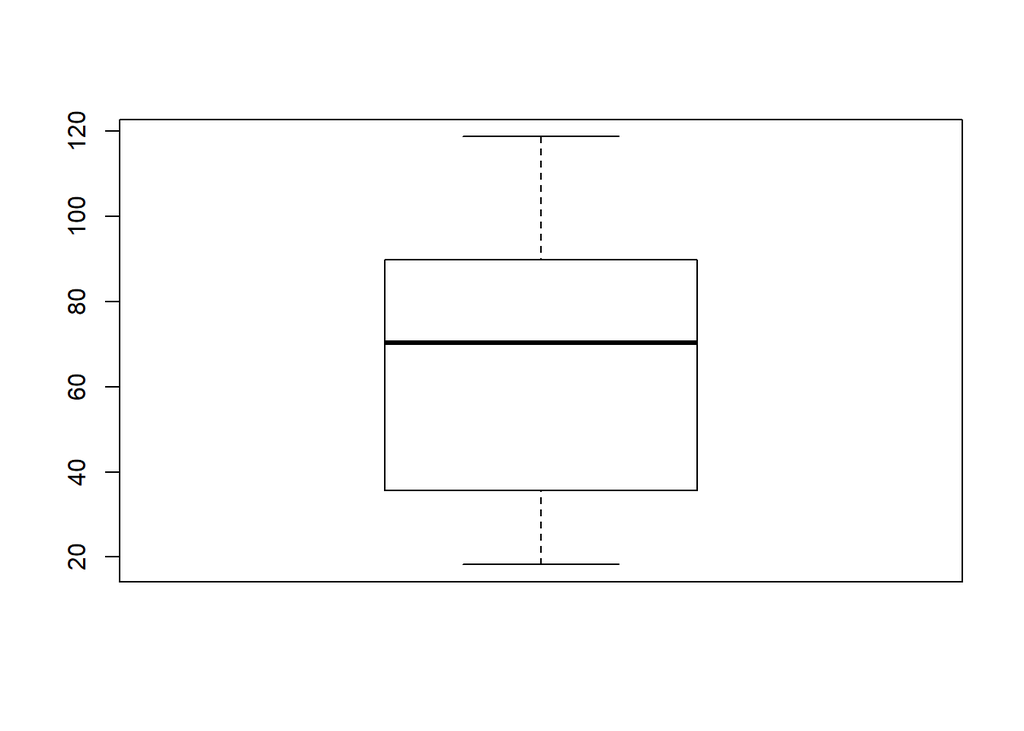

```
## numeric(0)
```

```r
boxplot(telco$MonthlyCharges)$out
```

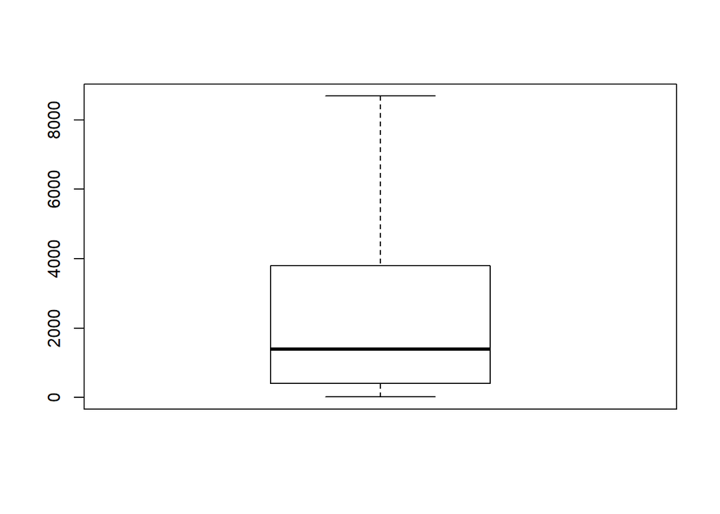

```
## numeric(0)
```

```r
boxplot(telco$TotalCharges)$out
```

# LIMPIANDO BASE DE DATOS:

Variables categáricas: Del análisis anterior sabemos que hay algunas características categóricas que tienen ‘No’ y ‘No hay servicio de Internet’ o ‘No hay servicio de teléfono’ como una categor?a. Entonces las cambiaremos por ‘No’.

```r
telco <- data.frame(lapply(telco, function(x) {
  gsub("No internet service", "No", x)}))

telco <- data.frame(lapply(telco, function(x) {
  gsub("No phone service", "No", x)}))
```

Las variables continuas no tienen el mismo rango, por lo tanto son estandarizadas:

```r
num_columns <- c("tenure", "MonthlyCharges", "TotalCharges")
telco[num_columns] <- sapply(telco[num_columns], as.numeric)

telco_int <- telco[,c("tenure", "MonthlyCharges", "TotalCharges")]
telco_int <- data.frame(scale(telco_int))
```

Creación de caracter?sticas derivadas: Se crea una variable que contiene rangos de tenencia

```r
max(telco$tenure)
```

```
## [1] 72
```

```r
min(telco$tenure)
```

```
## [1] 1
```

```r
telco <- mutate(telco, tenure_bin = tenure)

telco$tenure_bin[telco$tenure_bin >=0 & telco$tenure_bin <= 12] <- '0-1 year'
telco$tenure_bin[telco$tenure_bin > 12 & telco$tenure_bin <= 24] <- '1-2 years'
telco$tenure_bin[telco$tenure_bin > 24 & telco$tenure_bin <= 36] <- '2-3 years'
telco$tenure_bin[telco$tenure_bin > 36 & telco$tenure_bin <= 48] <- '3-4 years'
telco$tenure_bin[telco$tenure_bin > 48 & telco$tenure_bin <= 60] <- '4-5 years'
telco$tenure_bin[telco$tenure_bin > 60 & telco$tenure_bin <= 72] <- '5-6 years'

telco$tenure_bin <- as.factor(telco$tenure_bin)
```

El número máximo de clientes tiene una permanencia de 0-1 a?os. Seguidos de los que tienen entre 5-6 a?os.

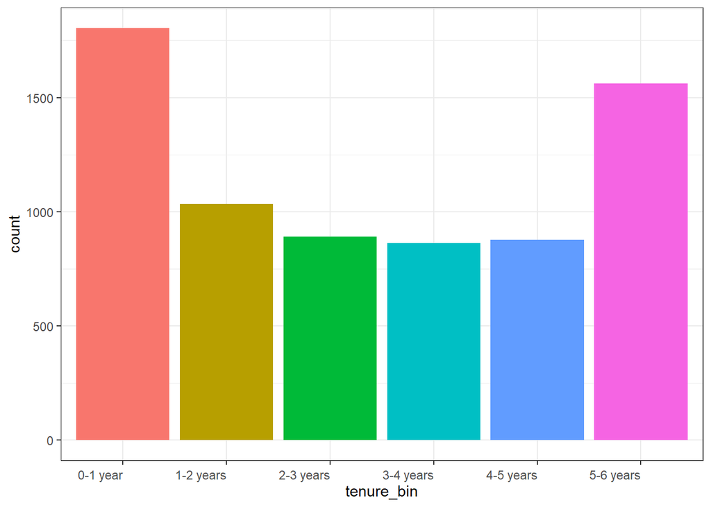

```r
# options(repr.plot.width =6, repr.plot.height = 3)
ggplot(telco, aes(tenure_bin, fill = tenure_bin)) + geom_bar()+ theme1
```

Creación de variables dummy: Porque varias est?n como caracter.

```r
telco_cat <- telco[,-c(1,6,19,20)]
dummy<- data.frame(sapply(telco_cat,function(x)
                   data.frame(model.matrix(~x-1,data =telco_cat))[,-1]))
head(dummy)
```

```
##   gender SeniorCitizen Partner Dependents PhoneService MultipleLines
## 1      0             0       1          0            0             0
## 2      1             0       0          0            1             0
## 3      1             0       0          0            1             0
## 4      1             0       0          0            0             0
## 5      0             0       0          0            1             0
## 6      0             0       0          0            1             1
##   InternetService.xFiber.optic InternetService.xNo OnlineSecurity
## 1                            0                   0              0
## 2                            0                   0              1
## 3                            0                   0              1
## 4                            0                   0              1
## 5                            1                   0              0
## 6                            1                   0              0
##   OnlineBackup DeviceProtection TechSupport StreamingTV StreamingMovies
```

[output cut: 41 more lines]

### Creamos la base final a utilizar: Continuas y dummys

```r
telco_final <- cbind(telco_int,dummy)
head(telco_final)
```

```
##       tenure MonthlyCharges TotalCharges gender SeniorCitizen Partner
## 1 -1.4265167    -0.72343522   -0.4019004      0             0       1
## 2 -0.2973877     0.03883410   -0.9528702      1             0       0
## 3 -0.9665012    -0.09429463   -1.6470178      1             0       0
## 4  0.2044474    -0.45717777   -0.9878692      1             0       0
## 5 -0.9665012     0.53484596   -1.2397562      0             0       0
## 6  1.5008548     1.70509041    1.5066078      0             0       0
##   Dependents PhoneService MultipleLines InternetService.xFiber.optic
## 1          0            0             0                            0
## 2          0            1             0                            0
## 3          0            1             0                            0
## 4          0            0             0                            0
## 5          0            1             0                            1
## 6          0            1             1                            1
##   InternetService.xNo OnlineSecurity OnlineBackup DeviceProtection
```

[output cut: 48 more lines]

# CONSTRUCCI?N DEL MODELO A UTILIZAR

## MODELO: REGRESI?N LOGISTICA.

Dividimos la base de datos en train y validation

```r
set.seed(123)
indices = sample.split(telco_final$Churn, SplitRatio = 0.7)
train = telco_final[indices,]
validation = telco_final[!(indices),]
```

## MODELO 1: Utilizando todas las variables

```r
model_1 = glm(Churn ~ ., data = train, family = "binomial")
summary(model_1)
```

```
##
## Call:
## glm(formula = Churn ~ ., family = "binomial", data = train)
##
## Deviance Residuals:
##     Min       1Q   Median       3Q      Max
## -1.8374  -0.6872  -0.2824   0.7156   3.1783
##
## Coefficients:
##                                        Estimate Std. Error z value
## (Intercept)                            -0.84717    0.35821  -2.365
## tenure                                 -0.47667    0.24990  -1.907
## MonthlyCharges                         -0.12170    0.04551  -2.674
## TotalCharges                            0.04640    0.04463   1.040
## gender                                 -0.03506    0.07697  -0.455
## SeniorCitizen                           0.23644    0.09901   2.388
## Partner                                -0.12961    0.09154  -1.416
## Dependents                             -0.12985    0.10844  -1.197
## PhoneService                           -0.18487    0.15464  -1.196
## MultipleLines                           0.01351    0.09145   0.148
## InternetService.xFiber.optic            0.85879    0.11296   7.602
## InternetService.xNo                    -1.27142    0.17510  -7.261
## OnlineSecurity                         -0.57214    0.10006  -5.718
## OnlineBackup                           -0.30795    0.08873  -3.471
## DeviceProtection                       -0.14125    0.09276  -1.523
## TechSupport                            -0.33273    0.10061  -3.307
## StreamingTV                             0.16300    0.09500   1.716
## StreamingMovies                         0.11068    0.09419   1.175
## Contract.xOne.year                     -1.10053    0.12243  -8.989
## Contract.xTwo.year                     -2.27320    0.22002 -10.332
## PaperlessBilling                        0.31895    0.08879   3.592
## PaymentMethod.xCredit.card..automatic. -0.03499    0.13527  -0.259
## PaymentMethod.xElectronic.check         0.41353    0.11097   3.726
## PaymentMethod.xMailed.check             0.15833    0.13458   1.176
## tenure_bin.x1.2.years                  -0.40086    0.18722  -2.141
## tenure_bin.x2.3.years                  -0.06387    0.29711  -0.215
## tenure_bin.x3.4.years                   0.02848    0.42135   0.068
## tenure_bin.x4.5.years                   0.10603    0.54003   0.196
## tenure_bin.x5.6.years                   0.49315    0.67447   0.731
##                                        Pr(>|z|)
```

[output cut: 24 more lines]

```
## tenure_bin.x1.2.years                  0.032261 *
## tenure_bin.x2.3.years                  0.829797
## tenure_bin.x3.4.years                  0.946112
## tenure_bin.x4.5.years                  0.844347
## tenure_bin.x5.6.years                  0.464679
## ---
## Signif. codes:  0 '***' 0.001 '**' 0.01 '*' 0.05 '.' 0.1 ' ' 1
##
## (Dispersion parameter for binomial family taken to be 1)
##
##     Null deviance: 5699.5  on 4921  degrees of freedom
## Residual deviance: 4133.8  on 4893  degrees of freedom
## AIC: 4191.8
##
## Number of Fisher Scoring iterations: 6
```

## MODELO 2: Ahora construimos el modelo utilizando el criterio stepAIC.

Este procedimiento quita o agrega variables iterativamente.

```r
model_2<- MASS::stepAIC(model_1, direction="both")
```

```
## Start:  AIC=4191.82
## Churn ~ tenure + MonthlyCharges + TotalCharges + gender + SeniorCitizen +
##     Partner + Dependents + PhoneService + MultipleLines + InternetService.xFiber.optic +
##     InternetService.xNo + OnlineSecurity + OnlineBackup + DeviceProtection +
##     TechSupport + StreamingTV + StreamingMovies + Contract.xOne.year +
##     Contract.xTwo.year + PaperlessBilling + PaymentMethod.xCredit.card..automatic. +
##     PaymentMethod.xElectronic.check + PaymentMethod.xMailed.check +
##     tenure_bin.x1.2.years + tenure_bin.x2.3.years + tenure_bin.x3.4.years +
##     tenure_bin.x4.5.years + tenure_bin.x5.6.years
##
##                                          Df Deviance    AIC
## - tenure_bin.x3.4.years                   1   4133.8 4189.8
## - MultipleLines                           1   4133.8 4189.8
## - tenure_bin.x4.5.years                   1   4133.9 4189.9
## - tenure_bin.x2.3.years                   1   4133.9 4189.9
## - PaymentMethod.xCredit.card..automatic.  1   4133.9 4189.9
## - gender                                  1   4134.0 4190.0
## - tenure_bin.x5.6.years                   1   4134.4 4190.4
## - TotalCharges                            1   4134.9 4190.9
## - StreamingMovies                         1   4135.2 4191.2
## - PaymentMethod.xMailed.check             1   4135.2 4191.2
## - PhoneService                            1   4135.2 4191.2
## - Dependents                              1   4135.3 4191.3
## <none>                                        4133.8 4191.8
## - Partner                                 1   4135.8 4191.8
## - DeviceProtection                        1   4136.1 4192.1
## - StreamingTV                             1   4136.8 4192.8
## - tenure                                  1   4137.5 4193.5
## - tenure_bin.x1.2.years                   1   4138.4 4194.4
## - SeniorCitizen                           1   4139.5 4195.5
## - MonthlyCharges                          1   4141.0 4197.0
## - TechSupport                             1   4144.9 4200.9
## - OnlineBackup                            1   4145.9 4201.9
## - PaperlessBilling                        1   4146.8 4202.8
## - PaymentMethod.xElectronic.check         1   4147.9 4203.9
## - OnlineSecurity                          1   4167.3 4223.3
## - InternetService.xNo                     1   4189.3 4245.3
## - InternetService.xFiber.optic            1   4194.1 4250.1
## - Contract.xOne.year                      1   4222.9 4278.9
## - Contract.xTwo.year                      1   4287.2 4343.2
```

[output cut: 418 more lines]

```
## - StreamingTV                             1   4148.0 4182.0
## - SeniorCitizen                           1   4150.4 4184.4
## - tenure_bin.x5.6.years                   1   4151.5 4185.5
## - MonthlyCharges                          1   4154.1 4188.1
## - TechSupport                             1   4154.5 4188.5
## - OnlineBackup                            1   4155.9 4189.9
## - PaperlessBilling                        1   4156.7 4190.7
## - tenure_bin.x1.2.years                   1   4159.7 4193.7
## - PaymentMethod.xElectronic.check         1   4165.5 4199.5
## - OnlineSecurity                          1   4178.2 4212.2
## - tenure                                  1   4198.3 4232.3
## - InternetService.xFiber.optic            1   4217.2 4251.2
## - InternetService.xNo                     1   4217.3 4251.3
## - Contract.xOne.year                      1   4234.2 4268.2
## - Contract.xTwo.year                      1   4298.8 4332.8
```

```r
summary(model_2)
```

```
##
## Call:
## glm(formula = Churn ~ tenure + MonthlyCharges + SeniorCitizen +
##     Partner + InternetService.xFiber.optic + InternetService.xNo +
##     OnlineSecurity + OnlineBackup + DeviceProtection + TechSupport +
##     StreamingTV + Contract.xOne.year + Contract.xTwo.year + PaperlessBilling +
##     PaymentMethod.xElectronic.check + tenure_bin.x1.2.years +
##     tenure_bin.x5.6.years, family = "binomial", data = train)
##
## Deviance Residuals:
##     Min       1Q   Median       3Q      Max
## -1.8219  -0.6956  -0.2849   0.7291   3.1348
##
## Coefficients:
##                                 Estimate Std. Error z value Pr(>|z|)
## (Intercept)                     -0.91679    0.12132  -7.557 4.12e-14 ***
## tenure                          -0.44998    0.06135  -7.334 2.23e-13 ***
## MonthlyCharges                  -0.14712    0.04436  -3.317 0.000911 ***
## SeniorCitizen                    0.26322    0.09668   2.723 0.006479 **
## Partner                         -0.18114    0.08198  -2.210 0.027129 *
## InternetService.xFiber.optic     0.82229    0.09690   8.486  < 2e-16 ***
## InternetService.xNo             -1.35302    0.16334  -8.284  < 2e-16 ***
## OnlineSecurity                  -0.58351    0.09967  -5.854 4.79e-09 ***
## OnlineBackup                    -0.31562    0.08829  -3.575 0.000351 ***
## DeviceProtection                -0.13699    0.09191  -1.490 0.136116
## TechSupport                     -0.33836    0.10030  -3.374 0.000742 ***
## StreamingTV                      0.19958    0.08993   2.219 0.026462 *
## Contract.xOne.year              -1.09534    0.12069  -9.076  < 2e-16 ***
## Contract.xTwo.year              -2.26453    0.21843 -10.367  < 2e-16 ***
## PaperlessBilling                 0.32478    0.08809   3.687 0.000227 ***
## PaymentMethod.xElectronic.check  0.38789    0.08160   4.754 2.00e-06 ***
## tenure_bin.x1.2.years           -0.42498    0.10530  -4.036 5.44e-05 ***
## tenure_bin.x5.6.years            0.46094    0.15838   2.910 0.003611 **
## ---
## Signif. codes:  0 '***' 0.001 '**' 0.01 '*' 0.05 '.' 0.1 ' ' 1
##
## (Dispersion parameter for binomial family taken to be 1)
##
##     Null deviance: 5699.5  on 4921  degrees of freedom
## Residual deviance: 4143.1  on 4904  degrees of freedom
## AIC: 4179.1
##
## Number of Fisher Scoring iterations: 6
```

Podemos usar el factor de inflaci?n de varianza (vif) para deshacernos de los predictores redundantes o las variables que tienen una alta multicolinealidad entre ellos. Un predictor que tiene un VIF de 2 o menos generalmente se considera bueno y se puede suponer que no está correlacionado con otras variables predictoras.

```r
vif(model_2)
```

```
##                          tenure                  MonthlyCharges
##                        2.292290                        1.394658
##                   SeniorCitizen                         Partner
##                        1.075635                        1.087978
##    InternetService.xFiber.optic             InternetService.xNo
##                        1.538351                        1.547107
##                  OnlineSecurity                    OnlineBackup
##                        1.087088                        1.151668
##                DeviceProtection                     TechSupport
##                        1.242012                        1.152511
##                     StreamingTV              Contract.xOne.year
##                        1.326082                        1.222888
##              Contract.xTwo.year                PaperlessBilling
##                        1.223435                        1.111802
## PaymentMethod.xElectronic.check           tenure_bin.x1.2.years
##                        1.129124                        1.052060
##           tenure_bin.x5.6.years
##                        2.007943
```

## MODELO 3:

Omitimos la variables DeviceProtection al no ser significativa en MODELO 2

```r
model_3 <-glm(formula = Churn ~ tenure + MonthlyCharges + SeniorCitizen +
                Partner + InternetService.xFiber.optic + InternetService.xNo +
                OnlineSecurity + OnlineBackup + TechSupport +
                StreamingTV + Contract.xOne.year + Contract.xTwo.year + PaperlessBilling +
                PaymentMethod.xElectronic.check + tenure_bin.x1.2.years +
                tenure_bin.x5.6.years, family = "binomial", data = train)
summary(model_3)
```

```
##
## Call:
## glm(formula = Churn ~ tenure + MonthlyCharges + SeniorCitizen +
##     Partner + InternetService.xFiber.optic + InternetService.xNo +
##     OnlineSecurity + OnlineBackup + TechSupport + StreamingTV +
##     Contract.xOne.year + Contract.xTwo.year + PaperlessBilling +
##     PaymentMethod.xElectronic.check + tenure_bin.x1.2.years +
##     tenure_bin.x5.6.years, family = "binomial", data = train)
##
## Deviance Residuals:
##     Min       1Q   Median       3Q      Max
## -1.8111  -0.6925  -0.2818   0.7279   3.1608
##
## Coefficients:
##                                 Estimate Std. Error z value Pr(>|z|)
## (Intercept)                     -0.94369    0.12007  -7.860 3.85e-15 ***
## tenure                          -0.45697    0.06119  -7.468 8.15e-14 ***
## MonthlyCharges                  -0.13809    0.04393  -3.143 0.001670 **
## SeniorCitizen                    0.26205    0.09660   2.713 0.006674 **
## Partner                         -0.18773    0.08185  -2.294 0.021804 *
## InternetService.xFiber.optic     0.80791    0.09627   8.392  < 2e-16 ***
## InternetService.xNo             -1.31592    0.16149  -8.149 3.67e-16 ***
## OnlineSecurity                  -0.58230    0.09962  -5.845 5.06e-09 ***
## OnlineBackup                    -0.31788    0.08825  -3.602 0.000316 ***
## TechSupport                     -0.34940    0.10002  -3.493 0.000477 ***
## StreamingTV                      0.17858    0.08870   2.013 0.044085 *
## Contract.xOne.year              -1.11807    0.11980  -9.333  < 2e-16 ***
## Contract.xTwo.year              -2.29697    0.21749 -10.561  < 2e-16 ***
## PaperlessBilling                 0.32567    0.08804   3.699 0.000216 ***
## PaymentMethod.xElectronic.check  0.39051    0.08154   4.789 1.67e-06 ***
## tenure_bin.x1.2.years           -0.42397    0.10524  -4.028 5.61e-05 ***
## tenure_bin.x5.6.years            0.47315    0.15823   2.990 0.002788 **
## ---
## Signif. codes:  0 '***' 0.001 '**' 0.01 '*' 0.05 '.' 0.1 ' ' 1
##
## (Dispersion parameter for binomial family taken to be 1)
##
##     Null deviance: 5699.5  on 4921  degrees of freedom
## Residual deviance: 4145.3  on 4905  degrees of freedom
## AIC: 4179.3
##
## Number of Fisher Scoring iterations: 6
```

```r
vif(model_3)
```

```
##                          tenure                  MonthlyCharges
##                        2.282029                        1.367104
##                   SeniorCitizen                         Partner
##                        1.075498                        1.085078
##    InternetService.xFiber.optic             InternetService.xNo
##                        1.519656                        1.509683
##                  OnlineSecurity                    OnlineBackup
##                        1.087319                        1.150754
##                     TechSupport                     StreamingTV
##                        1.145909                        1.291089
##              Contract.xOne.year              Contract.xTwo.year
##                        1.203896                        1.212871
##                PaperlessBilling PaymentMethod.xElectronic.check
##                        1.111438                        1.128411
##           tenure_bin.x1.2.years           tenure_bin.x5.6.years
##                        1.051896                        2.005468
```

# MODELO 4:

```r
model_4 <- glm(formula = Churn ~ tenure + MonthlyCharges + SeniorCitizen +
                 Partner + InternetService.xFiber.optic + InternetService.xNo +
                 OnlineSecurity + OnlineBackup + TechSupport +
                 Contract.xOne.year + Contract.xTwo.year + PaperlessBilling +
                 PaymentMethod.xElectronic.check + tenure_bin.x1.2.years +
                 tenure_bin.x5.6.years, family = "binomial", data = train)

summary(model_4)
```

```
##
## Call:
## glm(formula = Churn ~ tenure + MonthlyCharges + SeniorCitizen +
##     Partner + InternetService.xFiber.optic + InternetService.xNo +
##     OnlineSecurity + OnlineBackup + TechSupport + Contract.xOne.year +
##     Contract.xTwo.year + PaperlessBilling + PaymentMethod.xElectronic.check +
##     tenure_bin.x1.2.years + tenure_bin.x5.6.years, family = "binomial",
##     data = train)
##
## Deviance Residuals:
##     Min       1Q   Median       3Q      Max
## -1.8466  -0.6929  -0.2867   0.7300   3.1314
##
## Coefficients:
##                                 Estimate Std. Error z value Pr(>|z|)
## (Intercept)                     -0.91996    0.11932  -7.710 1.26e-14 ***
## tenure                          -0.44585    0.06087  -7.325 2.39e-13 ***
## MonthlyCharges                  -0.15098    0.04349  -3.472 0.000517 ***
## SeniorCitizen                    0.26448    0.09654   2.740 0.006153 **
## Partner                         -0.18177    0.08172  -2.224 0.026127 *
## InternetService.xFiber.optic     0.84836    0.09448   8.979  < 2e-16 ***
## InternetService.xNo             -1.36456    0.15948  -8.556  < 2e-16 ***
## OnlineSecurity                  -0.58578    0.09951  -5.887 3.94e-09 ***
## OnlineBackup                    -0.31295    0.08814  -3.551 0.000384 ***
## TechSupport                     -0.33539    0.09965  -3.366 0.000763 ***
## Contract.xOne.year              -1.08198    0.11826  -9.149  < 2e-16 ***
## Contract.xTwo.year              -2.25570    0.21630 -10.429  < 2e-16 ***
## PaperlessBilling                 0.34435    0.08751   3.935 8.32e-05 ***
## PaymentMethod.xElectronic.check  0.40760    0.08107   5.028 4.96e-07 ***
## tenure_bin.x1.2.years           -0.41708    0.10505  -3.970 7.18e-05 ***
## tenure_bin.x5.6.years            0.45941    0.15788   2.910 0.003616 **
## ---
## Signif. codes:  0 '***' 0.001 '**' 0.01 '*' 0.05 '.' 0.1 ' ' 1
##
## (Dispersion parameter for binomial family taken to be 1)
##
##     Null deviance: 5699.5  on 4921  degrees of freedom
## Residual deviance: 4149.3  on 4906  degrees of freedom
## AIC: 4181.3
##
## Number of Fisher Scoring iterations: 6
```

```r
vif(model_4)
```

```
##                          tenure                  MonthlyCharges
##                        2.257346                        1.343484
##                   SeniorCitizen                         Partner
##                        1.075457                        1.083303
##    InternetService.xFiber.optic             InternetService.xNo
##                        1.464481                        1.475564
##                  OnlineSecurity                    OnlineBackup
##                        1.087158                        1.149776
##                     TechSupport              Contract.xOne.year
##                        1.139849                        1.176187
##              Contract.xTwo.year                PaperlessBilling
##                        1.200134                        1.098677
## PaymentMethod.xElectronic.check           tenure_bin.x1.2.years
##                        1.116732                        1.050567
##           tenure_bin.x5.6.years
##                        1.997331
```

Utilicemos el MODELO 3 para predecir (inicialmente)

```r
final_model <- model_3
pred <- predict(final_model, type = "response", newdata = validation[,-24])
summary(pred)
```

```
##     Min.  1st Qu.   Median     Mean  3rd Qu.     Max.
## 0.006041 0.042040 0.194187 0.270761 0.486755 0.813298
```

```r
validation$prob <- pred
```

Cutoff: 50%

```r
pred_churn <- factor(ifelse(pred >= 0.50, "Yes", "No"))
actual_churn <- factor(ifelse(validation$Churn==1,"Yes","No"))
table(actual_churn,pred_churn)
```

```
##             pred_churn
## actual_churn   No  Yes
##          No  1364  185
##          Yes  249  312
```

Calculamos medidas de Accuracy, Sensitivity, Specificity utulizando el Cutoff de 50%

```r
cutoff_churn <- factor(ifelse(pred >=0.50, "Yes", "No"))
conf_final <- confusionMatrix(cutoff_churn, actual_churn, positive = "Yes")
accuracy <- conf_final$overall[1]
sensitivity <- conf_final$byClass[1]
specificity <- conf_final$byClass[2]
accuracy
```

```
##  Accuracy
## 0.7943128
```

```r
sensitivity
```

```
## Sensitivity
##   0.5561497
```

```r
specificity
```

```
## Specificity
##   0.8805681
```

Cuando se utiliza un cutoff de 50% se tiene un buen resultado en las medidas Accuracy y Specificity, pero la Sensitivity es menor. Entonces, necesitamos encontrar ese umbral en la probabilidad en que las tres medidas se desempe?an muy bien.

```r
perform_fn <- function(cutoff) {
  predicted_churn <- factor(ifelse(pred >= cutoff, "Yes", "No"))
  conf <- confusionMatrix(predicted_churn, actual_churn, positive = "Yes")
  accuray <- conf$overall[1]
  sensitivity <- conf$byClass[1]
  specificity <- conf$byClass[2]
  out <- t(as.matrix(c(sensitivity, specificity, accuray)))
  colnames(out) <- c("sensitivity", "specificity", "accuracy")
  return(out)
}

# options(repr.plot.width =8, repr.plot.height =6)
summary(pred)
```

```
##     Min.  1st Qu.   Median     Mean  3rd Qu.     Max.
## 0.006041 0.042040 0.194187 0.270761 0.486755 0.813298
```

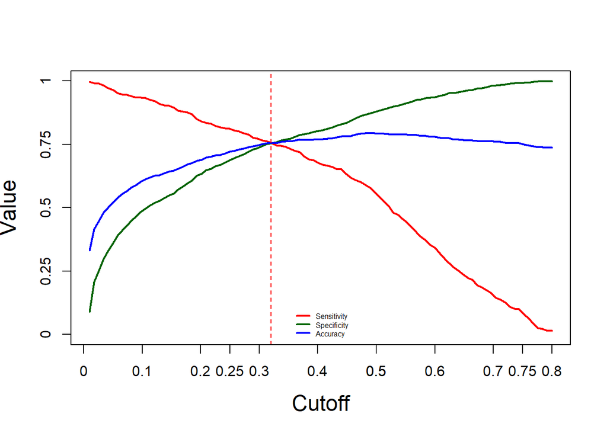

```r
s = seq(0.01,0.80,length=100)
OUT = matrix(0,100,3)

for(i in 1:100) {
  OUT[i,] = perform_fn(s[i]) }

plot(s, OUT[,1],xlab="Cutoff",ylab="Value",cex.lab=1.5,cex.axis=1.5,ylim=c(0,1),
     type="l",lwd=2,axes=FALSE,col=2)
axis(1,seq(0,1,length=5),seq(0,1,length=5),cex.lab=1.5)
axis(2,seq(0,1,length=5),seq(0,1,length=5),cex.lab=1.5)
lines(s,OUT[,2],col="darkgreen",lwd=2)
lines(s,OUT[,3],col=4,lwd=2)
box()
legend("bottom",col=c(2,"darkgreen",4,"darkred"),text.font =1,inset = 0.01,
       box.lty=0,cex = 0.5,
       lwd=c(2,2,2,2),c("Sensitivity","Specificity","Accuracy"))
abline(v = 0.32, col="red", lwd=1, lty=2)
axis(1, at = seq(0.1, 1, by = 0.1))
```

Utilizaremos un cutoff de 32%.

```r
cutoff_churn <- factor(ifelse(pred >=0.32, "Yes", "No"))
conf_final <- confusionMatrix(cutoff_churn, actual_churn, positive = "Yes")
accuracy <- conf_final$overall[1]
sensitivity <- conf_final$byClass[1]
specificity <- conf_final$byClass[2]
accuracy
```

```
##  Accuracy
## 0.7559242
```

```r
sensitivity
```

```
## Sensitivity
##   0.7575758
```

```r
specificity
```

```
## Specificity
##    0.755326
```

# MODELO: ÁRBOL DE DECISIÓN

```r
set.seed(123)
telco_final$Churn <- as.factor(telco_final$Churn)
indices = sample.split(telco_final$Churn, SplitRatio = 0.7)
train = telco_final[indices,]
validation = telco_final[!(indices),]
```

Entrenamos el árbol con todas las variables y predecimos “validation data”

```r
# options(repr.plot.width = 10, repr.plot.height = 8)
library(rpart)
library(rpart.plot)
```

#### Training

```r
Dtree = rpart(Churn ~., data = train, method = "class")
summary(Dtree)
```

```
## Call:
## rpart(formula = Churn ~ ., data = train, method = "class")
##   n= 4922
##
##           CP nsplit rel error    xerror       xstd
## 1 0.03720693      0 1.0000000 1.0000000 0.02369296
## 2 0.02675841      3 0.8883792 0.9159021 0.02301732
## 3 0.02599388      5 0.8348624 0.8899083 0.02279168
## 4 0.01223242      6 0.8088685 0.8470948 0.02240174
## 5 0.01000000      8 0.7844037 0.8310398 0.02224943
##
## Variable importance
##              Contract.xTwo.year              Contract.xOne.year
##                              22                              19
##                          tenure    InternetService.xFiber.optic
##                              13                              12
##                  MonthlyCharges             InternetService.xNo
##                              10                               4
##                   MultipleLines     PaymentMethod.xMailed.check
##                               4                               3
##                    TotalCharges           tenure_bin.x5.6.years
##                               3                               3
##                PaperlessBilling                  OnlineSecurity
##                               3                               2
## PaymentMethod.xElectronic.check
##                               1
##
## Node number 1: 4922 observations,    complexity param=0.03720693
##   predicted class=0  expected loss=0.2657456  P(node) =1
##     class counts:  3614  1308
##    probabilities: 0.734 0.266
##   left son=2 (1168 obs) right son=3 (3754 obs)
##   Primary splits:
##       Contract.xTwo.year              < 0.5        to the right, improve=179.0342, (0 missing)
##       InternetService.xFiber.optic    < 0.5        to the left,  improve=178.5663, (0 missing)
##       PaymentMethod.xElectronic.check < 0.5        to the left,  improve=171.0993, (0 missing)
##       tenure                          < -1.405607  to the right, improve=131.8187, (0 missing)
##       InternetService.xNo             < 0.5        to the right, improve=103.5056, (0 missing)
##   Surrogate splits:
##       tenure                < 1.354486   to the right, agree=0.804, adj=0.172, (0 split)
```

[output cut: 138 more lines]

```
##       PaymentMethod.xCredit.card..automatic. < 0.5        to the right, agree=0.751, adj=0.353, (0 split)
##       PaymentMethod.xMailed.check            < 0.5        to the right, agree=0.691, adj=0.197, (0 split)
##       TotalCharges                           < 1.513502   to the right, agree=0.620, adj=0.012, (0 split)
##       MonthlyCharges                         < 1.712606   to the right, agree=0.618, adj=0.007, (0 split)
##       Dependents                             < 0.5        to the right, agree=0.616, adj=0.002, (0 split)
##
## Node number 122: 402 observations
##   predicted class=0  expected loss=0.4577114  P(node) =0.08167412
##     class counts:   218   184
##    probabilities: 0.542 0.458
##
## Node number 123: 643 observations
##   predicted class=1  expected loss=0.4167963  P(node) =0.130638
##     class counts:   268   375
##    probabilities: 0.417 0.583
```

#### Predicting

```r
DTPred <- predict(Dtree,type = "class", newdata = validation[,-24])
```

Miramos la matriz de confusión

```r
confusionMatrix(validation$Churn, DTPred)
```

```
## Confusion Matrix and Statistics
##
##           Reference
## Prediction    0    1
##          0 1381  168
##          1  294  267
##
##                Accuracy : 0.781
##                  95% CI : (0.7628, 0.7985)
##     No Information Rate : 0.7938
##     P-Value [Acc > NIR] : 0.9297
##
##                   Kappa : 0.3958
##  Mcnemar's Test P-Value : 6.044e-09
##
##             Sensitivity : 0.8245
##             Specificity : 0.6138
##          Pos Pred Value : 0.8915
##          Neg Pred Value : 0.4759
##              Prevalence : 0.7938
##          Detection Rate : 0.6545
##    Detection Prevalence : 0.7341
##       Balanced Accuracy : 0.7191
##
##        'Positive' Class : 0
##
```

El modelo de ?rbol de decisión (precisi?n - 78,1%) proporciona una precisi?n ligeramente mejor con respecto al modelo de regresi?n log?stica (precisi?n 75%). La sensibilidad tambi?n es mejor en el caso del ?rbol de decisi?n que es 82.45%. Sin embargo, la especificidad ha disminuido a 61.38% en el caso del ?rbol de Decisi?n en comparaci?n con el modelo de regresi?n log?stica.

# MODELO: RANDOM FOREST

```r
set.seed(123)
telco_final$Churn <- as.factor(telco_final$Churn)
indices = sample.split(telco_final$Churn, SplitRatio = 0.7)
train = telco_final[indices,]
validation = telco_final[!(indices),]

model.rf <- randomForest(Churn ~ ., data=train, proximity=FALSE,importance = FALSE,
                         ntree=500,mtry=4, do.trace=FALSE)
model.rf
```

```
##
## Call:
##  randomForest(formula = Churn ~ ., data = train, proximity = FALSE,      importance = FALSE, ntree = 500, mtry = 4, do.trace = FALSE)
##                Type of random forest: classification
##                      Number of trees: 500
## No. of variables tried at each split: 4
##
##         OOB estimate of  error rate: 20.99%
## Confusion matrix:
##      0   1 class.error
## 0 3266 348   0.0962922
## 1  685 623   0.5237003
```

```r
testPred <- predict(model.rf, newdata=validation[,-24])
table(testPred, validation$Churn)
```

```
##
## testPred    0    1
##        0 1404  301
##        1  145  260
```

```r
confusionMatrix(validation$Churn, testPred)
```

```
## Confusion Matrix and Statistics
##
##           Reference
## Prediction    0    1
##          0 1404  145
##          1  301  260
##
##                Accuracy : 0.7886
##                  95% CI : (0.7706, 0.8059)
##     No Information Rate : 0.8081
##     P-Value [Acc > NIR] : 0.9884
##
##                   Kappa : 0.4058
##  Mcnemar's Test P-Value : 2.145e-13
##
##             Sensitivity : 0.8235
##             Specificity : 0.6420
##          Pos Pred Value : 0.9064
##          Neg Pred Value : 0.4635
##              Prevalence : 0.8081
##          Detection Rate : 0.6654
##    Detection Prevalence : 0.7341
##       Balanced Accuracy : 0.7327
##
##        'Positive' Class : 0
##
```

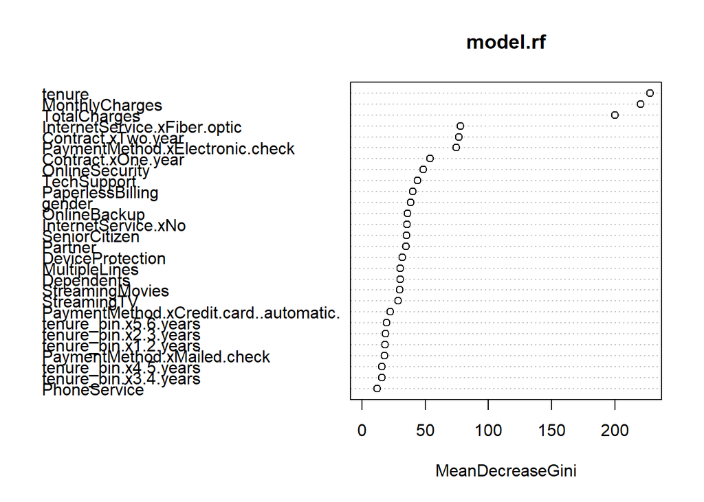

```r
varImpPlot(model.rf)
```

A continuaci?n se muestra la gr?fica de importancia variable, que muestra el atributo m?s significativo en orden decreciente por la disminuci?n media en Gini. La disminuci?n media Gini mide la pureza de los nodos al final del árbol. Cuanto m?s alto es el ?ndice de Gini, mejor es la homogeneidad.

# IDENTIFICANDO EL MEJOR MODELO

Miramos el área bajo la curva de ROC (AUC):

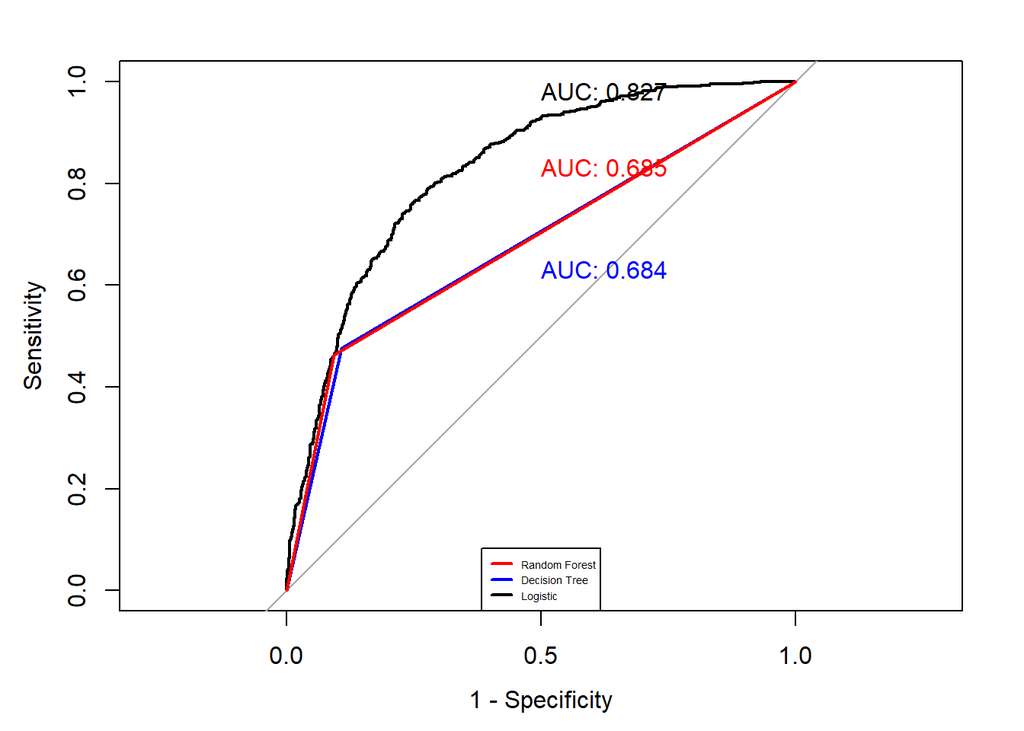

```r
# options(repr.plot.width =10, repr.plot.height = 8)

glm.roc <- roc(response = validation$Churn, predictor = as.numeric(pred))
DT.roc <- roc(response = validation$Churn, predictor = as.numeric(DTPred))
rf.roc <- roc(response = validation$Churn, predictor = as.numeric(testPred))

plot(glm.roc,      legacy.axes = TRUE, print.auc.y = 1.0, print.auc = TRUE)
plot(DT.roc, col = "blue", add = TRUE, print.auc.y = 0.65, print.auc = TRUE)
plot(rf.roc, col = "red" , add = TRUE, print.auc.y = 0.85, print.auc = TRUE)
legend("bottom", c("Random Forest", "Decision Tree", "Logistic"),
       lty = c(1,1), lwd = c(2, 2), col = c("red", "blue", "black"), cex = 0.45)
```

# RESUMEN DE TODOS LOS MODELOS:

### Logistic Regression:

Accuracy 75.59%, Sensitivity 75.75% Specificity 75.53%

### DecisionTrees:

Accuracy 78.1%, Sensitivity 82.45% Specificity 61.38%